# Measles Across the Globe

Author

Natalie Cartwright, Zita Tam, Aryan Nair, Amanda Dong

# Introduction

News of measles outbreaks are constantly being released. Despite vaccines, measles continues to affect the whole world. The World Health Organization collects data on monthly measles and rubella cases across the world. We will be focusing on measles cases, as it’s typically more severe and contagious compared to rubella. We were provided with data on suspected measles cases, confirmed cases, and total cases. The World Health Organization provides these counts for each country, and by two time frames: monthly and yearly (2012 to 2025). All data is provisional and is reported by a country’s WHO member each year.

In addition to our measles data, we will also be using data collected from API Ninja on Air Quality for each country. The website does not explicitly say where they collected the Air Quality data from. We were provided with data on several major pollutants, but will focus on the overall Air Quality Index (AQI). The Air Quality Index is a globally used measurement that ranges from 0 to 500, with higher values meaning worse air pollution The index is calculated based on the 5 major air pollutants. All information on air quality provided are the latest known data.

```r
library(httr)
library(tidyjson)
library(jsonlite)
library(tidyverse)
library(stringr)
library(gt)
library(paletteer)
cases_month <- readr::read_csv('https://raw.githubusercontent.com/rfordatascience/tidytuesday/main/data/2025/2025-06-24/cases_month.csv')
cases_year <- readr::read_csv('https://raw.githubusercontent.com/rfordatascience/tidytuesday/main/data/2025/2025-06-24/cases_year.csv')
```

## Has the total number of reported measles cases increased or decreased over time globally?

To answer this question, we first needed to determine how each country’s total number of measles cases was changing year-by-year. To do this, we compared each sequential year and categorized the change as declining (if the previous year had more cases), surging (if the previous year had less cases), and stable (if cases stayed relatively the same).

```r
trend_label <- function(current, previous) {
  pct_change <- (current - previous) / previous * 100
  case_when(
    pct_change < -20 ~ "declining",
    pct_change >  20 ~ "surging",
    .default = "stable"
  )
}

yearly_summary <- cases_year |>
  group_by(year) |>
  summarise(
    total_cases = sum(measles_total, na.rm = TRUE),
    n_countries = n_distinct(country),
    .groups = "drop"
  ) |>
  arrange(year) |>
  mutate(
    prev_total = lag(total_cases),
    pct_change = round((total_cases - prev_total) / prev_total * 100, 1),
    trend = trend_label(total_cases, prev_total)
  ) |>
  select(year, total_cases, n_countries, pct_change, trend)
```

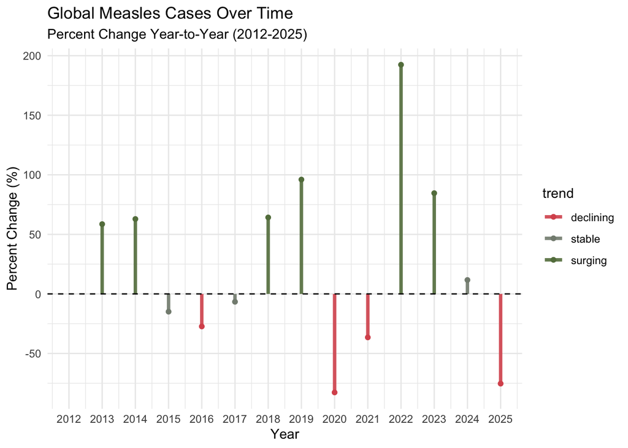

Figure 1: Percent Change in measles cases

```r
ggplot(yearly_summary, aes(x = year, xend = year, y = 0, yend = pct_change,
                           color = trend)) +
  geom_segment(size = 1.3, alpha = 0.9) +
  geom_point(aes(y = pct_change)) +
  theme_minimal() +
  theme(panel.border = element_blank()) +
  scale_x_continuous(breaks = yearly_summary$year) +
  scale_y_continuous(breaks = seq(-100, 200, by = 50)) +
  geom_hline(yintercept = 0, linetype = "dashed") +
    labs(title = "Global Measles Cases Over Time", subtitle = "Percent Change Year-to-Year (2012-2025)") +
  xlab("Year") + ylab("Percent Change (%)") +
  scale_color_manual(values = c(surging = "#647D4BFF",
                      declining = "#D9565CFF",
                      stable = "#848C80"))
```

Not only were we interested in looking at how measles cases changed over time, but we also wanted to know if there has been a change in the methods of finding measles over time. The number of total measles cases for each country, month, and year is made up of 3 possible methods of detecting measles: Clinically-compatible, Epidemiologically-linked, and Laboratory-confirmed. Let’s see if the proportion of each method has changed throughout the years.

```r
methods <- list(clin_prop = "clinical",
                epi_prop = "epi",
                lab_prop = "lab")

cases_filtered <- cases_year %>% filter(!is.na(measles_clinical),
                                     !is.na(measles_total),
                                     !is.na(measles_epi_linked),
                                     !is.na(measles_lab_confirmed))
yearly_totals <- cases_filtered %>% group_by(year) %>%
  summarise(
    total = sum(measles_total),
    clinical = sum(measles_clinical),
    epi = sum(measles_epi_linked),
    lab = sum(measles_lab_confirmed),
    .groups = "drop")

props <- function(col) {
  yearly_totals[[col]] / yearly_totals$total
}

propsbyyear <- bind_cols(
  select(yearly_totals, year),
  map_dfc(methods, props)
)

plot_long <- propsbyyear %>%
  pivot_longer(cols = c(clin_prop, epi_prop, lab_prop),
               names_to = "method",
               values_to = "proportion")
```

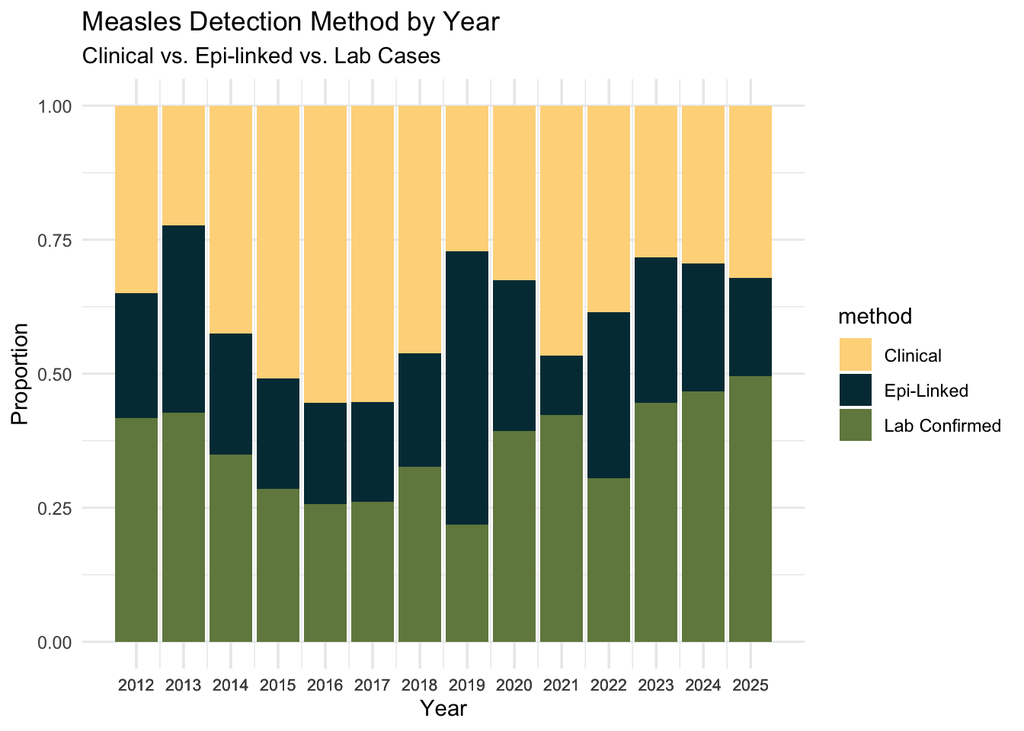

Figure 2: Method of Finding Measles Year-by-Year

```r
ggplot(plot_long, aes(x = year, y = proportion, fill = method)) +
  geom_bar(position = "fill", stat = "identity") +
  scale_x_continuous(breaks = plot_long$year) +
  theme_minimal() +
  theme(axis.text.x = element_text(size = 8)) +
  labs(title = "Measles Detection Method by Year",
       subtitle = "Clinical vs. Epi-linked vs. Lab Cases") +
  xlab("Year") +
  ylab("Proportion") +
  scale_fill_paletteer_d("nationalparkcolors::Acadia",
                         labels = c(clin_prop = "Clinical",
                                 epi_prop = "Epi-Linked",
                                 lab_prop = "Lab Confirmed"))
```